# Filtering Postural Data Using a Butterworth Filter

```r
library(BalanceMate)
  library(knitr)
  library(kableExtra)
```

```r
  library(ggplot2)
```

Butterworth_it.R

## Description

Signal processing often involves removing noise or smoothing data to improve interpretability. In postural data, tiny spikes in signals can complicate analysis. Filtering is a common approach to address these issues, with the Butterworth filter being one of the most popular methods. This vignette demonstrates how to use the `Butterworth_it` function from the `BalanceMate` package to apply a Butterworth filter to postural data, including examples of its application.

### A short digression on signals

Cut-Off Frequency usage in the literature

| Cut-off Frequency used | Number of papers |
| --- | --- |
| 10Hz | 5 |
| 15Hz | 1 |
| 20Hz | 1 |
| 5Hz | 8 |
| 8Hz | 1 |
| No filter used | 25 |
| Not enough information | 2 |
| Other | 1 |

Filter’s order usage in the literature

| Order of the filter used | Number of papers |
| --- | --- |
| 2nd Order | 10 |
| 3rd Order | 1 |
| N/A | 26 |
| Unknown | 7 |

Butterworth_it.R

Regarding high vs low-pass; it appears all filters either mention explicitly using a low-pass filter, or do not report which type of filter they used.

*Note*: *other types of filter where 5-points moving average (n = 1).*

### Usage example

Butterworth filter is by far the most used type of filter. It is a wrapper of the `filtfilt` and `butter` commands of the `signal` package. To use it, you need to specify the column(s) you want to filter, indicate the order you want to use, the cut-off frequency for the filter, and whether you would like a high or low-pass filter to be applied.

*Note*: *the filter is used on the raw data, before any synthesis is done. It can be applied to the moments and forces (used to compute CoP), or on the CoP itself – this does not produce much difference from what I have tested. Because the filter is applied on raw data, the computation might take some time for large datasets.*

Based on the literature and the popularity of this specific filter (see Monéger et al., 2024 [preprint]), you want to use a **2nd order Butterworth filter** with a **cut-off frequency of 5Hz.**

*Note: the files are stored as Rdata to reduce the size of the package – however the command only accepts txt files, hence it is required to first convert Rdata to text files before running the examples*

```r
#Data<-Merge_PosData("~/Desktop/BalanceMate/inst/extdata/", SampleRate = 100, SessionDuration = 100)

# If required: convert Rdata to txt files:
files <- list(
    "Postural_DataA" = "~/Desktop/BalanceMate/data/Postural_DataA.Rdata",
    "Postural_DataB" = "~/Desktop/BalanceMate/data/Postural_DataB.Rdata",
    "Postural_DataC" = "~/Desktop/BalanceMate/data/Postural_DataC.Rdata",
    "Postural_DataD" = "~/Desktop/BalanceMate/data/Postural_DataD.Rdata",
    "Postural_DataE" = "~/Desktop/BalanceMate/data/Postural_DataE.Rdata",
    "Postural_DataF" = "~/Desktop/BalanceMate/data/Postural_DataF.Rdata"
)

# Loop through each file, add a blank row with spaces, and save as .txt
for (name in names(files)) {
    # Load the .Rdata file
    load(files[[name]])

    # Dynamically get the object loaded (assuming it's named the same as the file)
    data <- get(name)

    # Add a "blank" row (spaces for all cells) at the top
    #blank_row <- rep(" ", 6)  # Create a row of spaces with the same number of columns
    #data <- rbind(blank_row, data)

    # Write to a .txt file with the same name
    write.table(data, file = paste0(name, ".txt"), sep = ",", row.names = FALSE, col.names = FALSE, quote = FALSE)
}

Data<-Merge_PosData(".", SampleRate = 100, SessionDuration = 100)

filtered_data <- Butterworth_it(
  Data = Data,
  cutoff_freq = 5,
  filter_order = 2,
  sampling_rate = 100,
  type = "low",
  Colname = c("CoP_X", "CoP_Y")
)
```

Butterworth_it.R

The resulting data file contains now one column with the raw untransformed signal and one column with the filtered signal.

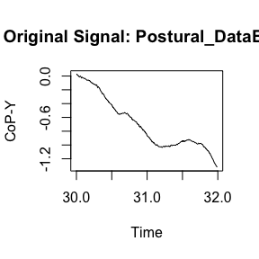

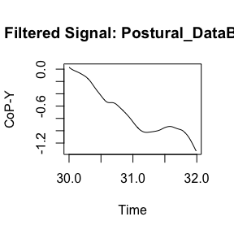

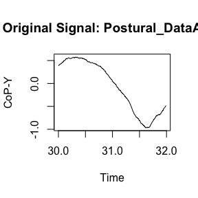

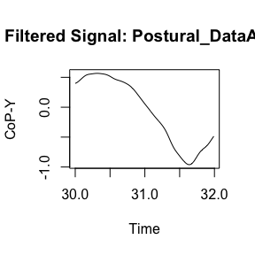

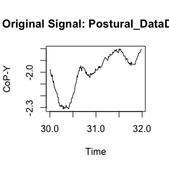

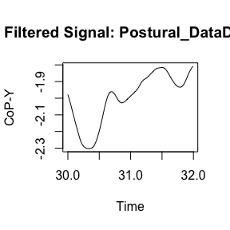

```r
# File names
file_names <- c("Postural_DataB.txt", "Postural_DataA.txt", "Postural_DataD.txt")

# Loop through file names to generate plots side by side
for (file in file_names) {
  # Original signal plot
  plot(
    x = subset(filtered_data, filtered_data$file_name == file & filtered_data$Time > 30 & filtered_data$Time < 32)$Time,
    y = subset(filtered_data, filtered_data$file_name == file & filtered_data$Time > 30 & filtered_data$Time < 32)$CoP_Y,
    type = "l",
    main = paste("Original Signal:", file),
    xlab = "Time",
    ylab = "CoP-Y"
  )

  # Filtered signal plot
  plot(
    x = subset(filtered_data, filtered_data$file_name == file & filtered_data$Time > 30 & filtered_data$Time < 32)$Time,
    y = subset(filtered_data, filtered_data$file_name == file & filtered_data$Time > 30 & filtered_data$Time < 32)$CoP_Y_filtered,
    type = "l",
    main = paste("Filtered Signal:", file),
    xlab = "Time",
    ylab = "CoP-Y"
  )
}
```

Butterworth_it.R

### Further readings

I recommend reading the documentation of the [`signal`](https://cran.r-project.org/web/packages/signal/index.html) package and the chapter of the [BalanceMate book](https://jeanmoneger.com/book/pre-processing).